# Assignment 3: Margin of Error in Poverty in Philadelphia

Fact Checking ‘New Census figures on Philly neighborhoods show inequality, high numbers of whites living in poverty’

Published

September 25, 2026

```r
library(readr)
WHYY_data <- read_csv("assignments/WHYY_data.csv")
View(WHYY_data)
```

He separately reported also using the 2015-2016 and 2016-2017 one-year estimate that percent of white people in poverty skyrocketed from “14.8% to 19.4% between 2016 and 2017.” Using the 2013-2017 5-year ACS, he cites poverty rates among white residents of Holmesburg have jumped from 2% to 19% in the period.

These results are alarming and disturbing. They also need to be subject to further scrutiny if we are to make policy surrounding where to allocate limited city resources to address growing needs among the populace. Specifically, they need to take margin of error into account, as if they don’t we could end up over- or under-allocating to the wrong neighborhoods. For example, according to Lubrano’s analysis, Powelton, Hunting Park, and Mantua have the highest percent in poverty in the 2013-2017 survey and are all relatively equal. It would therefore make sense to focus allocation of further city resources to these areas; however, should we account for margin of error and find that one has the potential to be 10+ percentage points higher than another, it may affect our decision-making.

This report will therefore attempt to fill in these gaps on the census tract level so that we can better track where percent poverty and median household income has changed throughout the city – both in total and by race – so that we can better plan for future allocation of city resources to the most vulnerable regions.

```r
library(tidyverse)
library(tidycensus)
```

First, we will download the same data that Lubrano relied on for his analysis, but by census tract:

1. 5-year: 2006-2010 and 2013-2017
   1. Total poverty rate
   2. White poverty rate
   3. median household income
2. 1-year: 2016-2017
   1. White poverty rate (countywide)

We are using census tracts as neighborhood boundaries are not official and can often be disputed; on the other hand, census tracts are standardized by the Federal Government. One issue here though is that census tract boundaries also change, so this may affect our results.

Second, the analyses for 5-year changes have a 3-year gap in between their windows and therefore do not overlap; we can can therefore compare them with each other. However, the 1-year estimates overlap with the latter 5-year window. It is therefore best to analyze these separately as it does not take every year (2013-2015) into account.

Third, the author does not specify whether for change median household income he adjusted for inflation. For this exercise, we will not adjust for inflation.

Finally, the article does not state what their metric for “poverty” is. Is he looking at below 100%, 100-149%, or at or above 150%? For sake of ease, we will be using tables that ignore these percentages.

Note that while the author looked specifically at “majority-white neighborhoods,” we will consider all census tracts, regardless whether they are majority white.

First, we will get total population, total poverty, white population, white poverty, and median household income information for 2013-2017. We can also add columns for percent in poverty and the margin of error for this percent using *moe_prop()*:

```r
#2013-2017
vars <- load_variables(2017, "acs5")
View(vars)

PA <- "PA"
variables17 <- c(
  total_pov_17 = "B17001_002",
  pop_17   = "B01003_001",
  median_hh_inc_17 = "B19013_001",
  white_pop_17 = "B17001H_001",
  white_pov_17 = "B17001H_002")


pov17 <- get_acs(
  geography = "tract",
  variables = variables17,
  state = "PA",
  county = "Philadelphia County",
  year = 2017,
  survey = "acs5",
  output = "wide") %>%
    mutate(
      share_17     = total_pov_17E / pop_17E,
      share_moe_17 = moe_prop(total_pov_17E, pop_17E,
                           total_pov_17M, pop_17M),
      white_share_17     = white_pov_17E / white_pop_17E,
      white_share_moe_17 = moe_prop(white_pov_17E, white_pop_17E,
                              white_pov_17M, white_pop_17M)
    )
```

And we can do the same for 2006-2010:

```r
#2006-2010

#the variable codes are the same as for 2017

PA <- "PA"
variables10 <- c(
  total_pov_10 = "B17001_002",
  pop_10   = "B01003_001",
  median_hh_inc_10 = "B19013_001",
  white_pop_10 = "B17001H_001",
  white_pov_10 = "B17001H_002")


pov10 <- get_acs(
  geography = "tract",
  variables = variables10,
  state = "PA",
  county = "Philadelphia County",
  year = 2010,
  survey = "acs5",
  output = "wide") %>%
  mutate(
    share_10     = total_pov_10E / pop_10E,
    share_moe_10 = moe_prop(total_pov_10E, pop_10E,
                            total_pov_10M, pop_10M),
    white_share_10     = white_pov_10E / white_pop_10E,
    white_share_moe_10 = moe_prop(white_pov_10E, white_pop_10E,
                                  white_pov_10M, white_pop_10M)
  )
```

We can now join them together (and drop superfluous columns) for further analysis:

```r
pov_comp <- full_join(pov10,
                      pov17,
                      by = "GEOID",
                      copy = FALSE) %>%
  select(-c(NAME.y, total_pov_10E, total_pov_10M, total_pov_17E, total_pov_17M, pop_10E, pop_10M, pop_17E, pop_17M)
)
```

While he did not state it directly, to create a comparison for 2016 to 2017 city-wide change in white poverty from the 1-year census, he must have also used the 1-year 2015-2016 ACS as well. We will therefore download data from both:

First, the 2016-2017

```r
PA <- "PA"
white_var17 <- c(
  white_pop_17 = "B17001H_001",
  white_pov_17   = "B17001H_002")


white_pov17 <- get_acs(
  geography = "county",
  variables = white_var17,
  state = "PA",
  county = "Philadelphia County",
  year = 2017,
  survey = "acs1",
  output = "wide") %>%
  mutate(
    white_share_17     = white_pov_17E / white_pop_17E,
    white_share_moe_17 = moe_prop(white_pov_17E, white_pop_17E,
                            white_pov_17M, white_pop_17M)
  )
```

```r
PA <- "PA"
white_var16 <- c(
  white_pop_16 = "B17001H_001",
  white_pov_16   = "B17001H_002")


white_pov16 <- get_acs(
  geography = "county",
  variables = white_var16,
  state = "PA",
  county = "Philadelphia County",
  year = 2016,
  survey = "acs1",
  output = "wide") %>%
  mutate(
    white_share_16     = white_pov_16E / white_pop_16E,
    white_share_moe_16 = moe_prop(white_pov_16E, white_pop_16E,
                            white_pov_16M, white_pop_16M)
  )
```

We can now also combine these 1-year data together into one table:

```r
white_pov_comp <- full_join(white_pov16,
                      white_pov17,
                      by = "GEOID",
                      copy = FALSE) %>%
  select(-c(NAME.y, white_pov_16E, white_pov_16M, white_pov_17E, white_pov_17M, white_pop_16E, white_pop_16M, white_pop_17E, white_pop_17M)
  )
```

We tested whether the change was statistically distinguishable from zero at 90% confidence. In other words, we chekced in which tracts does the margin of error *not* cross 0.

First, for change total poverty rate and white poverty rate:

```r
pov_change <- pov_comp %>%
  mutate(
    change   = `share_17` - `share_10`,
    se_1     = `share_moe_10` / 1.645,
    se_2     = `share_moe_17` / 1.645,
    se_diff  = sqrt(se_1^2 + se_2^2),
    moe_diff = se_diff * 1.645,
    z        = change / se_diff,
    significant = abs(z) > 1.645
  )

pov_change %>%
  count(significant)
```

```
# A tibble: 3 × 2
  significant     n
  <lgl>       <int>
1 FALSE         310
2 TRUE           66
3 NA              8
```

```r
pov_change %>%
  filter(significant == "TRUE") %>%
  count(change > 0 )
```

```
# A tibble: 2 × 2
  `change > 0`     n
  <lgl>        <int>
1 FALSE           29
2 TRUE            37
```

```r
white_pov_change <- pov_comp %>%
  mutate(
    change   = `white_share_17` - `white_share_10`,
    se_1     = `white_share_moe_10` / 1.645,
    se_2     = `white_share_moe_17` / 1.645,
    se_diff  = sqrt(se_1^2 + se_2^2),
    moe_diff = se_diff * 1.645,
    z        = change / se_diff,
    significant = abs(z) > 1.645
  )

white_pov_change %>%
  count(significant)
```

```
# A tibble: 3 × 2
  significant     n
  <lgl>       <int>
1 FALSE         304
2 TRUE           62
3 NA             18
```

```r
white_pov_change %>%
  filter(significant == "TRUE") %>%
  count(change > 0 )
```

```
# A tibble: 2 × 2
  `change > 0`     n
  <lgl>        <int>
1 FALSE           26
2 TRUE            36
```

```r
white_pov_change1yr <- white_pov_comp %>%
  mutate(
    change   = `white_share_17` - `white_share_16`,
    se_1     = `white_share_moe_16` / 1.645,
    se_2     = `white_share_moe_17` / 1.645,
    se_diff  = sqrt(se_1^2 + se_2^2),
    moe_diff = se_diff * 1.645,
    z        = change / se_diff,
    significant = abs(z) > 1.645
  )

white_pov_change1yr %>%
  count(significant)
```

```
# A tibble: 1 × 2
  significant     n
  <lgl>       <int>
1 TRUE            1
```

```r
white_pov_change1yr %>%
  filter(significant == "TRUE") %>%
  count(change > 0 )
```

```
# A tibble: 1 × 2
  `change > 0`     n
  <lgl>        <int>
1 TRUE             1
```

As can be seen in the tables above, we found that for the total poverty rate, the change is statistically significant in only 66 census tracts and not statistically significant in 310 tracts. 8 census tracts are NA. These are all non-populated areas of Philadelphia, such as the airports, parks, and stadium district. They will therefore be disregarded for the remainder of the report. We can also see that of these 66 tracts, 37 (56%) saw an increase in poverty rate.

For the white poverty rate at the 5-year level, only 62 tracts are statistically significant, while 304 are not. 18 are NA because they are either non-populated or have a very low number of estimated white residents. And for these 36 tracts (58%) saw an increase in percentage of white people in poverty.

Then at the 1-year level (without directly comparing it to the 5-year), we can also see that the single reading for Philadelphia is statistically significant and that there was an overall increase in percentage of white people in poverty.

We then visualized the positive and negative change in the total and white poverty rate between the two periods and margins of error among the 15 census tracts with the absolute highest change in each category (increase vs decrease). We opted for 15 observations as this would still capture a large portion of census tracts, but still be concise for readability. Of course, for the 1-year change, we have only one observation:

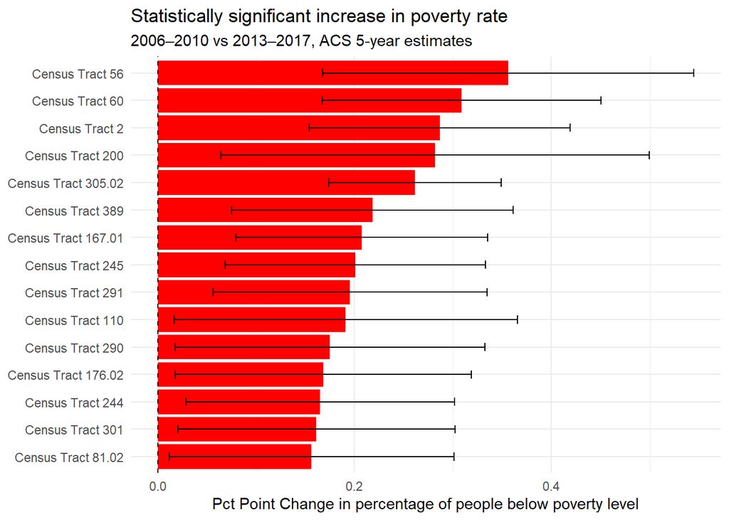

```r
#Total
#Increase in Poverty Rate
pov_change %>%
  filter(significant) %>% #just keeping the ones that are significant
  mutate(NAME = str_remove(NAME.x, ", Philadelphia County, Pennsylvania")) %>%
  filter (change > 0) %>%
  arrange(desc(change)) %>%
  slice_head(n = 15) %>%
  ggplot(aes(x = reorder(NAME, change), y = change)) +
  geom_col(fill = "red") +
  geom_errorbar(aes(ymin = change - moe_diff,
                    ymax = change + moe_diff), width = 0.3) +
  geom_hline(yintercept = 0, linetype = "dashed") +
  coord_flip() +
  theme_minimal() +
  labs(title = "Statistically significant increase in poverty rate",
       subtitle = "2006–2010 vs 2013–2017, ACS 5-year estimates",
       x = NULL, y = "Pct Point Change in percentage of people below poverty level")
```

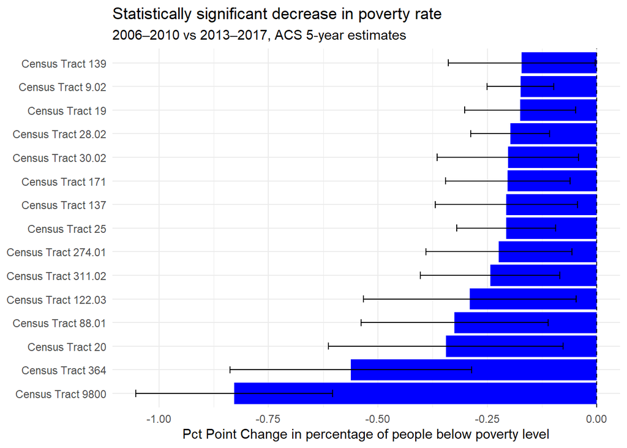

```r
#Decrease in Poverty Rate
pov_change %>%
  filter(significant) %>% #just keeping the ones that are significant
  mutate(NAME = str_remove(NAME.x, ", Philadelphia County, Pennsylvania")) %>%
  filter (change < 0) %>%
  arrange(change) %>%
  slice_head(n = 15) %>%
  ggplot(aes(x = reorder(NAME, change), y = change)) +
  geom_col(fill = "blue") +
  geom_errorbar(aes(ymin = change - moe_diff,
                    ymax = change + moe_diff), width = 0.3) +
  geom_hline(yintercept = 0, linetype = "dashed") +
  coord_flip() +
  theme_minimal() +
  labs(title = "Statistically significant decrease in poverty rate",
       subtitle = "2006–2010 vs 2013–2017, ACS 5-year estimates",
       x = NULL, y = "Pct Point Change in percentage of people below poverty level")
```

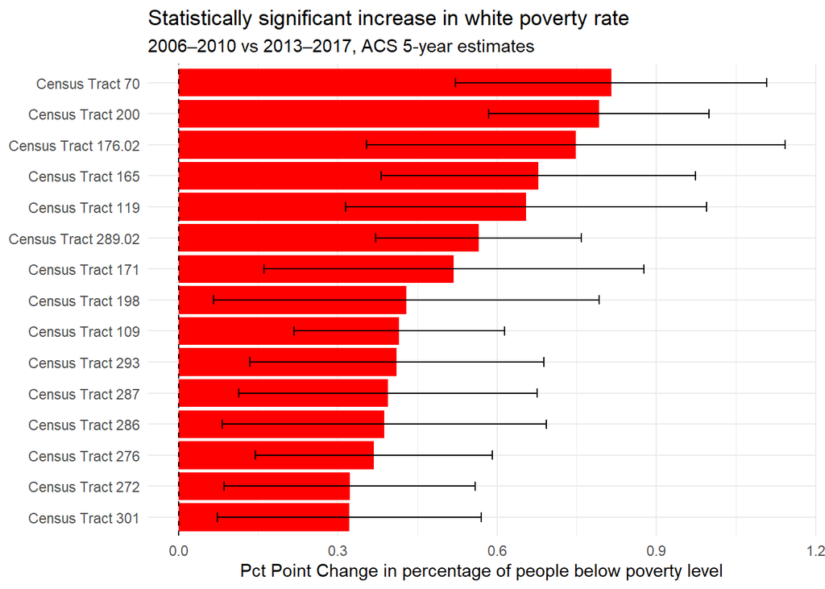

```r
#White
#Increase in White Poverty Rate
white_pov_change %>%
  filter(significant) %>% #just keeping the ones that are significant
  mutate(NAME = str_remove(NAME.x, ", Philadelphia County, Pennsylvania")) %>%
  filter (change > 0) %>%
  arrange(desc(change)) %>%
  slice_head(n = 15) %>%
  ggplot(aes(x = reorder(NAME, change), y = change)) +
  geom_col(fill = "red") +
  geom_errorbar(aes(ymin = change - moe_diff,
                    ymax = change + moe_diff), width = 0.3) +
  geom_hline(yintercept = 0, linetype = "dashed") +
  coord_flip() +
  theme_minimal() +
  labs(title = "Statistically significant increase in white poverty rate",
       subtitle = "2006–2010 vs 2013–2017, ACS 5-year estimates",
       x = NULL, y = "Pct Point Change in percentage of people below poverty level")
```

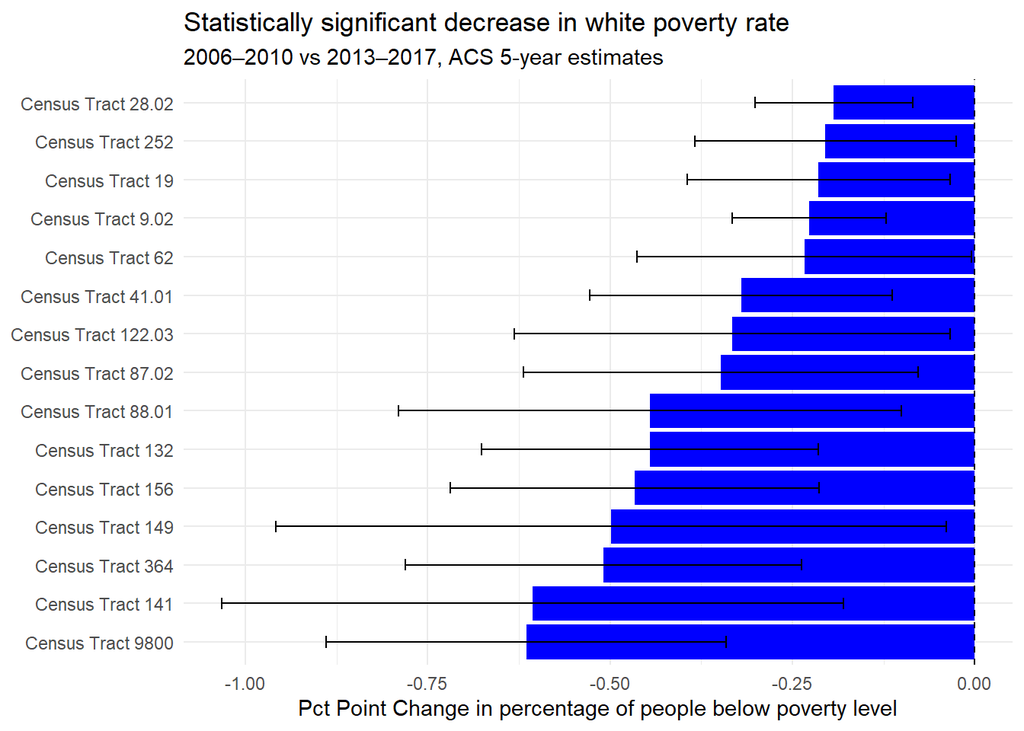

```r
#Decrease in White Poverty Rate
white_pov_change %>%
  filter(significant) %>% #just keeping the ones that are significant
  mutate(NAME = str_remove(NAME.x, ", Philadelphia County, Pennsylvania")) %>%
  filter (change < 0) %>%
  arrange(change) %>%
  slice_head(n = 15) %>%
  ggplot(aes(x = reorder(NAME, change), y = change)) +
  geom_col(fill = "blue") +
  geom_errorbar(aes(ymin = change - moe_diff,
                    ymax = change + moe_diff), width = 0.3) +
  geom_hline(yintercept = 0, linetype = "dashed") +
  coord_flip() +
  theme_minimal() +
  labs(title = "Statistically significant decrease in white poverty rate",
       subtitle = "2006–2010 vs 2013–2017, ACS 5-year estimates",
       x = NULL, y = "Pct Point Change in percentage of people below poverty level")
```

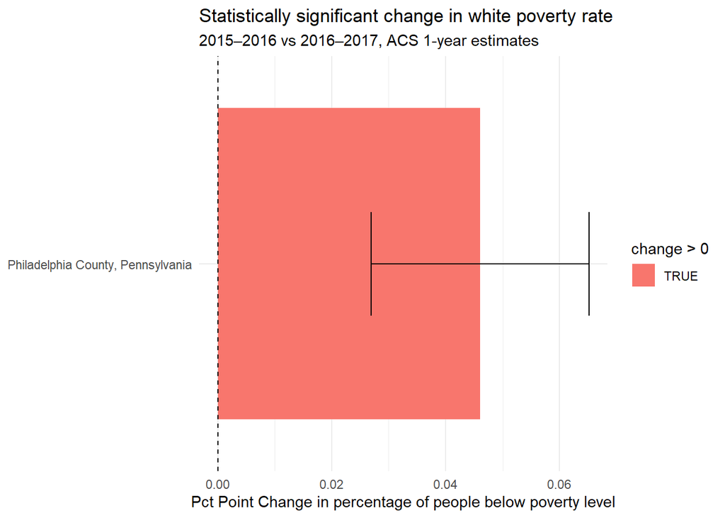

```r
#Poverty 1-year
white_pov_change1yr %>%
  filter(significant) %>% #just keeping the ones that are significant
  mutate(NAME = str_remove(NAME.x, ", Philadelphia County, Pennsylvania")) %>%
  arrange(desc(abs(change))) %>%
  slice_head(n = 1) %>%
  ggplot(aes(x = reorder(NAME, change), y = change)) +
  geom_col(aes(fill = change > 0)) +
  geom_errorbar(aes(ymin = change - moe_diff,
                    ymax = change + moe_diff), width = 0.3) +
  geom_hline(yintercept = 0, linetype = "dashed") +
  coord_flip() +
  theme_minimal() +
  labs(title = "Statistically significant change in white poverty rate",
       subtitle = "2015–2016 vs 2016–2017, ACS 1-year estimates",
       x = NULL, y = "Pct Point Change in percentage of people below poverty level")
```

We then performed the same analysis for change in median household income:

```r
inc_change <- pov_comp %>%
  mutate(
    change   = `median_hh_inc_17E` - `median_hh_inc_10E`,
    se_1     = `median_hh_inc_10M` / 1.645,
    se_2     = `median_hh_inc_17M` / 1.645,
    se_diff  = sqrt(se_1^2 + se_2^2),
    moe_diff = se_diff * 1.645,
    z        = change / se_diff,
    significant = abs(z) > 1.645
  )

inc_change %>%
  count(significant)
```

```
# A tibble: 3 × 2
  significant     n
  <lgl>       <int>
1 FALSE         296
2 TRUE           78
3 NA             10
```

```r
inc_change %>%
  filter(significant == "TRUE") %>%
  count(change < 0 )
```

```
# A tibble: 2 × 2
  `change < 0`     n
  <lgl>        <int>
1 FALSE           66
2 TRUE            12
```

As can be seen above, 78 census tracts are now statistically significant and 296 are not – slightly better than poverty rate. Here there are two additional NA census tracts, since they had an estimated population, but not an estimated median household income. They will also be disregarded for future analysis. Of these 78 tracts, only 12 (15%) had median household income decrease.

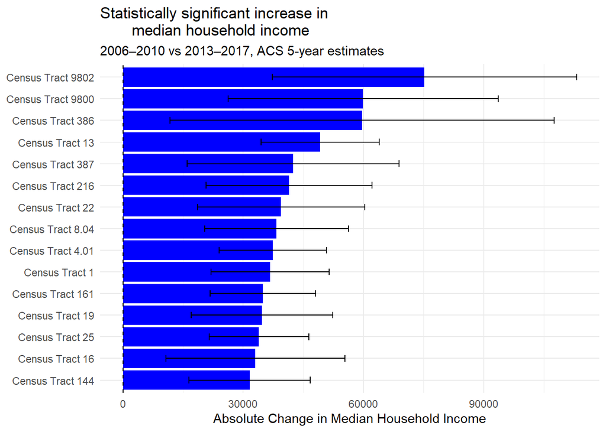

```r
#Positive
inc_change %>%
  filter(significant) %>% #just keeping the ones that are significant
  mutate(NAME = str_remove(NAME.x, ", Philadelphia County, Pennsylvania")) %>%
  filter (change > 0) %>%
  arrange(desc(change)) %>%
  slice_head(n = 15) %>%
  ggplot(aes(x = reorder(NAME, change), y = change)) +
  geom_col(fill = "blue") +
  geom_errorbar(aes(ymin = change - moe_diff,
                    ymax = change + moe_diff), width = 0.3) +
  geom_hline(yintercept = 0, linetype = "dashed") +
  coord_flip() +
  theme_minimal() +
  labs(title = "Statistically significant increase in
       median household income",
       subtitle = "2006–2010 vs 2013–2017, ACS 5-year estimates",
       x = NULL, y = "Absolute Change in Median Household Income")
```

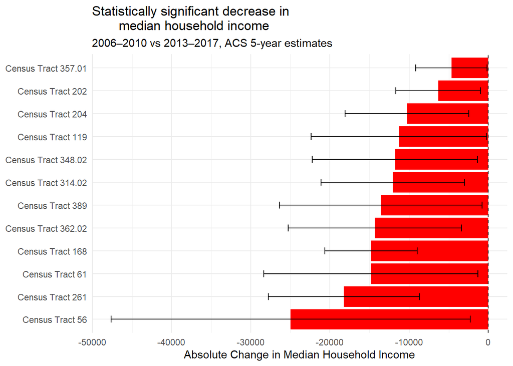

```r
#Negative
inc_change %>%
  filter(significant) %>% #just keeping the ones that are significant
  mutate(NAME = str_remove(NAME.x, ", Philadelphia County, Pennsylvania")) %>%
  filter (change < 0) %>%
  arrange(change) %>%
  slice_head(n = 15) %>%
  ggplot(aes(x = reorder(NAME, change), y = change)) +
  geom_col(fill = "red") +
  geom_errorbar(aes(ymin = change - moe_diff,
                    ymax = change + moe_diff), width = 0.3) +
  geom_hline(yintercept = 0, linetype = "dashed") +
  coord_flip() +
  theme_minimal() +
  labs(title = "Statistically significant decrease in
       median household income",
       subtitle = "2006–2010 vs 2013–2017, ACS 5-year estimates",
       x = NULL, y = "Absolute Change in Median Household Income")
```

To assess the reliability of our census tract data, we computed the coefficient of variation and flagged the reliability using the Jurjevich (2018) thresholds:

- CV <12% = reliable
- CV 12-40% = somewhat reliable
- CV >40% = unreliable

First, for the poverty rate in 2013-2017 and 2016-2017:

```r
library(gt)

#Total: 5-year
rel_table_pov17 <- pov_comp %>%
  mutate(
    cv = (share_moe_17 / 1.645) / share_17 * 100,
    dot = case_when(
      cv < 12  ~ "🟢",
      cv <= 40 ~ "🟡",
      TRUE     ~ "🔴"
    ),
    flag = case_when(
      cv < 12  ~ "Reliable",
      cv <= 40 ~ "Somewhat reliable",
      TRUE     ~ "Unreliable"
    ),
    NAME = str_remove(NAME.x, ", Philadelphia County, Pennsylvania")
  ) %>%
  arrange(desc(cv))

rel_table_pov17 %>%
  select(dot, NAME, share_17, share_moe_17, cv, flag)  %>%
  gt() %>%
  fmt_number(columns = c(share_17, share_moe_17), decimals = 0) %>%
  fmt_number(columns = cv, decimals = 1) %>%
  cols_label(
    dot      = "",
    NAME     = "Tract",
    share_17 = "Estimate",
    share_moe_17      = "MOE",
    cv       = "CV (%)",
    flag     = "Reliability"
  ) %>%
  cols_align(align = "center", columns = dot) %>%
  tab_header(
    title    = "Percent population below poverty level",
    subtitle = "Philadelphia Census Tracts, ACS 2013-2017 5-year estimates"
  ) %>%
  tab_source_note(
    "Reliability thresholds follow Jurjevich et al. (2018): CV < 12% reliable, 12–40% somewhat reliable, > 40% unreliable."
  )
```

Percent population below poverty level

Philadelphia Census Tracts, ACS 2013-2017 5-year estimates

|  | Tract | Estimate | MOE | CV (%) | Reliability |
| --- | --- | --- | --- | --- | --- |
| 🔴 | Census Tract 9891 | 0 | 0 | 98.7 | Unreliable |
| 🔴 | Census Tract 9800 | 0 | 0 | 79.5 | Unreliable |
| 🔴 | Census Tract 231 | 0 | 0 | 66.7 | Unreliable |
| 🔴 | Census Tract 256 | 0 | 0 | 64.7 | Unreliable |
| 🔴 | Census Tract 9801 | 0 | 0 | 61.5 | Unreliable |
| 🔴 | Census Tract 386 | 0 | 0 | 59.3 | Unreliable |
| 🔴 | Census Tract 9802 | 0 | 0 | 50.6 | Unreliable |
| 🔴 | Census Tract 340 | 0 | 0 | 47.9 | Unreliable |
| 🔴 | Census Tract 347.02 | 0 | 0 | 47.1 | Unreliable |
| 🔴 | Census Tract 10.02 | 0 | 0 | 46.7 | Unreliable |
| 🔴 | Census Tract 220 | 0 | 0 | 45.3 | Unreliable |
| 🔴 | Census Tract 363.03 | 0 | 0 | 44.2 | Unreliable |
| 🔴 | Census Tract 29 | 0 | 0 | 43.4 | Unreliable |
| 🔴 | Census Tract 341 | 0 | 0 | 42.4 | Unreliable |
| 🔴 | Census Tract 365.01 | 0 | 0 | 42.2 | Unreliable |
| 🔴 | Census Tract 8.01 | 0 | 0 | 41.9 | Unreliable |
| 🔴 | Census Tract 4.02 | 0 | 0 | 41.5 | Unreliable |
| 🔴 | Census Tract 236 | 0 | 0 | 41.2 | Unreliable |
| 🔴 | Census Tract 366 | 0 | 0 | 40.6 | Unreliable |
| 🔴 | Census Tract 356.02 | 0 | 0 | 40.3 | Unreliable |
| 🔴 | Census Tract 235 | 0 | 0 | 40.0 | Unreliable |
| 🔴 | Census Tract 365.02 | 0 | 0 | 40.0 | Unreliable |
| 🟡 | Census Tract 352 | 0 | 0 | 40.0 | Somewhat reliable |
| 🟡 | Census Tract 10.01 | 0 | 0 | 39.9 | Somewhat reliable |
| 🟡 | Census Tract 40.02 | 0 | 0 | 39.5 | Somewhat reliable |
| 🟡 | Census Tract 12.01 | 0 | 0 | 39.4 | Somewhat reliable |
| 🟡 | Census Tract 385 | 0 | 0 | 39.2 | Somewhat reliable |
| 🟡 | Census Tract 344 | 0 | 0 | 38.6 | Somewhat reliable |
| 🟡 | Census Tract 362.03 | 0 | 0 | 38.5 | Somewhat reliable |
| 🟡 | Census Tract 361 | 0 | 0 | 38.5 | Somewhat reliable |

[output cut: 354 more lines]

Reliability thresholds follow Jurjevich et al. (2018): CV < 12% reliable, 12–40% somewhat reliable, > 40% unreliable.

```r
#White: 5-year
white_rel_table_pov17 <- pov_comp %>%
  mutate(
    cv = (white_share_moe_17 / 1.645) / white_share_17 * 100,
    dot = case_when(
      cv < 12  ~ "🟢",
      cv <= 40 ~ "🟡",
      TRUE     ~ "🔴"
    ),
    flag = case_when(
      cv < 12  ~ "Reliable",
      cv <= 40 ~ "Somewhat reliable",
      TRUE     ~ "Unreliable"
    ),
    NAME = str_remove(NAME.x, ", Philadelphia County, Pennsylvania")
  ) %>%
  arrange(desc(cv))

white_rel_table_pov17 %>%
  select(dot, NAME, white_share_17, white_share_moe_17, cv, flag) %>%
  gt() %>%
  fmt_number(columns = c(white_share_17, white_share_moe_17), decimals = 0) %>%
  fmt_number(columns = cv, decimals = 1) %>%
  cols_label(
    dot      = "",
    NAME     = "Tract",
    white_share_17 = "Estimate",
    white_share_moe_17      = "MOE",
    cv       = "CV (%)",
    flag     = "Reliability"
  ) %>%
  cols_align(align = "center", columns = dot) %>%
  tab_header(
    title    = "Percent population below poverty level",
    subtitle = "Philadelphia Census Tracts, ACS 2013-2017 5-year estimates"
  ) %>%
  tab_source_note(
    "Reliability thresholds follow Jurjevich et al. (2018): CV < 12% reliable, 12–40% somewhat reliable, > 40% unreliable."
  )
```

Percent population below poverty level

Philadelphia Census Tracts, ACS 2013-2017 5-year estimates

|  | Tract | Estimate | MOE | CV (%) | Reliability |
| --- | --- | --- | --- | --- | --- |
| 🔴 | Census Tract 73 | 0 | 0 | Inf | Unreliable |
| 🔴 | Census Tract 82 | 0 | 0 | Inf | Unreliable |
| 🔴 | Census Tract 84 | 0 | 0 | Inf | Unreliable |
| 🔴 | Census Tract 256 | 0 | 0 | Inf | Unreliable |
| 🔴 | Census Tract 258 | 0 | 0 | Inf | Unreliable |
| 🔴 | Census Tract 259 | 0 | 0 | Inf | Unreliable |
| 🔴 | Census Tract 263.01 | 0 | 0 | Inf | Unreliable |
| 🔴 | Census Tract 277 | 0 | 0 | Inf | Unreliable |
| 🔴 | Census Tract 62 | 0 | 0 | Inf | Unreliable |
| 🔴 | Census Tract 9800 | 0 | 0 | Inf | Unreliable |
| 🔴 | Census Tract 9891 | 1 | 3 | 200.6 | Unreliable |
| 🔴 | Census Tract 266 | 1 | 3 | 171.9 | Unreliable |
| 🔴 | Census Tract 148 | 1 | 3 | 170.9 | Unreliable |
| 🔴 | Census Tract 100 | 0 | 0 | 140.1 | Unreliable |
| 🔴 | Census Tract 262 | 0 | 1 | 120.7 | Unreliable |
| 🔴 | Census Tract 264 | 1 | 2 | 114.6 | Unreliable |
| 🔴 | Census Tract 267 | 0 | 0 | 107.8 | Unreliable |
| 🔴 | Census Tract 95 | 1 | 2 | 101.9 | Unreliable |
| 🔴 | Census Tract 71.02 | 0 | 0 | 99.0 | Unreliable |
| 🔴 | Census Tract 152 | 1 | 2 | 95.1 | Unreliable |
| 🔴 | Census Tract 263.02 | 0 | 0 | 90.8 | Unreliable |
| 🔴 | Census Tract 253 | 0 | 0 | 88.8 | Unreliable |
| 🔴 | Census Tract 260 | 0 | 0 | 88.6 | Unreliable |
| 🔴 | Census Tract 81.02 | 0 | 0 | 88.3 | Unreliable |
| 🔴 | Census Tract 105 | 0 | 0 | 85.2 | Unreliable |
| 🔴 | Census Tract 98.02 | 0 | 0 | 84.4 | Unreliable |
| 🔴 | Census Tract 9802 | 0 | 0 | 83.7 | Unreliable |
| 🔴 | Census Tract 110 | 0 | 0 | 82.2 | Unreliable |
| 🔴 | Census Tract 249 | 1 | 1 | 81.2 | Unreliable |
| 🔴 | Census Tract 254 | 0 | 0 | 80.4 | Unreliable |

[output cut: 354 more lines]

Reliability thresholds follow Jurjevich et al. (2018): CV < 12% reliable, 12–40% somewhat reliable, > 40% unreliable.

```r
#White: 1-year
white_rel_table_pov17_1yr <- white_pov_comp %>%
  mutate(
    cv = (white_share_moe_17 / 1.645) / white_share_17 * 100,
    dot = case_when(
      cv < 12  ~ "🟢",
      cv <= 40 ~ "🟡",
      TRUE     ~ "🔴"
    ),
    flag = case_when(
      cv < 12  ~ "Reliable",
      cv <= 40 ~ "Somewhat reliable",
      TRUE     ~ "Unreliable"
    ),
    NAME = str_remove(NAME.x, ", Philadelphia County, Pennsylvania")
  ) %>%
  arrange(desc(cv))

white_rel_table_pov17_1yr %>%
  select(dot, NAME, white_share_17, white_share_moe_17, cv, flag) %>%
  gt() %>%
  fmt_number(columns = c(white_share_17, white_share_moe_17), decimals = 0) %>%
  fmt_number(columns = cv, decimals = 1) %>%
  cols_label(
    dot      = "",
    NAME     = "Tract",
    white_share_17 = "Estimate",
    white_share_moe_17      = "MOE",
    cv       = "CV (%)",
    flag     = "Reliability"
  ) %>%
  cols_align(align = "center", columns = dot) %>%
  tab_header(
    title    = "Percent population below poverty level",
    subtitle = "Philadelphia Census Tracts, ACS 2016-2017 1-year estimates"
  ) %>%
  tab_source_note(
    "Reliability thresholds follow Jurjevich et al. (2018): CV < 12% reliable, 12–40% somewhat reliable, > 40% unreliable."
  )
```

Percent population below poverty level

Philadelphia Census Tracts, ACS 2016-2017 1-year estimates

|  | Tract | Estimate | MOE | CV (%) | Reliability |
| --- | --- | --- | --- | --- | --- |
| 🟢 | Philadelphia County, Pennsylvania | 0 | 0 | 4.4 | Reliable |

Reliability thresholds follow Jurjevich et al. (2018): CV < 12% reliable, 12–40% somewhat reliable, > 40% unreliable.

Second, for the median household income for 2013-2017:

```r
rel_table_inc <- pov_comp %>%
  mutate(
    cv = (median_hh_inc_17M / 1.645) / median_hh_inc_17E * 100,
    dot = case_when(
      cv < 12  ~ "🟢",
      cv <= 40 ~ "🟡",
      TRUE     ~ "🔴"
    ),
    flag = case_when(
      cv < 12  ~ "Reliable",
      cv <= 40 ~ "Somewhat reliable",
      TRUE     ~ "Unreliable"
    ),
    NAME = str_remove(NAME.x, ", Philadelphia County, Pennsylvania")
  ) %>%
  arrange(desc(cv))

rel_table_inc %>%
  select(dot, NAME, median_hh_inc_17E, median_hh_inc_17M, cv, flag) %>%
  gt() %>%
  fmt_number(columns = c(median_hh_inc_17E, median_hh_inc_17M), decimals = 0) %>%
  fmt_number(columns = cv, decimals = 1) %>%
  cols_label(
    dot      = "",
    NAME     = "Tract",
    median_hh_inc_17E = "Estimate",
    median_hh_inc_17M      = "MOE",
    cv       = "CV (%)",
    flag     = "Reliability"
  ) %>%
  cols_align(align = "center", columns = dot) %>%
  tab_header(
    title    = "Median Household Income",
    subtitle = "Philadelphia Census Tracts, ACS 2016-2017 1-year estimates"
  ) %>%
  tab_source_note(
    "Reliability thresholds follow Jurjevich et al. (2018): CV < 12% reliable, 12–40% somewhat reliable, > 40% unreliable."
  )
```

Median Household Income

|  | Tract | Estimate | MOE | CV (%) | Reliability |
| --- | --- | --- | --- | --- | --- |
| 🔴 | Census Tract 66 | 17,254 | 11,923 | 42.0 | Unreliable |
| 🟡 | Census Tract 274.01 | 26,492 | 16,492 | 37.8 | Somewhat reliable |
| 🟡 | Census Tract 264 | 39,653 | 23,838 | 36.5 | Somewhat reliable |
| 🟡 | Census Tract 177.01 | 19,250 | 11,093 | 35.0 | Somewhat reliable |
| 🟡 | Census Tract 117 | 57,813 | 33,257 | 35.0 | Somewhat reliable |
| 🟡 | Census Tract 172.02 | 15,395 | 8,735 | 34.5 | Somewhat reliable |
| 🟡 | Census Tract 88.01 | 18,125 | 10,004 | 33.6 | Somewhat reliable |
| 🟡 | Census Tract 81.01 | 20,100 | 10,420 | 31.5 | Somewhat reliable |
| 🟡 | Census Tract 239 | 21,667 | 10,936 | 30.7 | Somewhat reliable |
| 🟡 | Census Tract 287 | 20,288 | 10,230 | 30.7 | Somewhat reliable |
| 🟡 | Census Tract 246 | 22,143 | 11,086 | 30.4 | Somewhat reliable |
| 🟡 | Census Tract 177.02 | 14,167 | 6,955 | 29.8 | Somewhat reliable |
| 🟡 | Census Tract 95 | 21,788 | 10,356 | 28.9 | Somewhat reliable |
| 🟡 | Census Tract 104 | 18,575 | 8,784 | 28.7 | Somewhat reliable |
| 🟡 | Census Tract 210 | 59,063 | 27,760 | 28.6 | Somewhat reliable |
| 🟡 | Census Tract 148 | 16,550 | 7,725 | 28.4 | Somewhat reliable |
| 🟡 | Census Tract 156 | 21,875 | 10,131 | 28.2 | Somewhat reliable |
| 🟡 | Census Tract 235 | 65,500 | 30,102 | 27.9 | Somewhat reliable |
| 🟡 | Census Tract 9801 | 100,156 | 45,778 | 27.8 | Somewhat reliable |
| 🟡 | Census Tract 165 | 9,945 | 4,532 | 27.7 | Somewhat reliable |
| 🟡 | Census Tract 381 | 32,083 | 14,466 | 27.4 | Somewhat reliable |
| 🟡 | Census Tract 147 | 12,662 | 5,693 | 27.3 | Somewhat reliable |
| 🟡 | Census Tract 207 | 65,385 | 29,048 | 27.0 | Somewhat reliable |
| 🟡 | Census Tract 88.02 | 21,250 | 9,436 | 27.0 | Somewhat reliable |
| 🟡 | Census Tract 249 | 28,417 | 12,516 | 26.8 | Somewhat reliable |
| 🟡 | Census Tract 111 | 23,548 | 10,223 | 26.4 | Somewhat reliable |
| 🟡 | Census Tract 286 | 25,625 | 10,897 | 25.9 | Somewhat reliable |
| 🟡 | Census Tract 132 | 19,569 | 8,319 | 25.8 | Somewhat reliable |
| 🟡 | Census Tract 199 | 14,838 | 6,278 | 25.7 | Somewhat reliable |
| 🟡 | Census Tract 101 | 41,875 | 17,537 | 25.5 | Somewhat reliable |

[output cut: 354 more lines]

Reliability thresholds follow Jurjevich et al. (2018): CV < 12% reliable, 12–40% somewhat reliable, > 40% unreliable.

#3 Adjudicating the Article